# **Supplemental Materials:** Statements issued by academic medical institutions after George Floyd’s killing by police and subsequent unrest in the United States: cross-sectional study’

Mathew V Kiang and Alexander C Tsai

```r
library(tidyverse)
library(here)
library(DT)
library(knitr)
```

```r
## Read in processed data
analytic_df <- readRDS(here("data_private", "analytic_df.RDS"))
word_df <- readRDS(here("data_private", "tokenized_words.RDS"))
sentence_df <- readRDS(here("data_private", "tokenized_sentences.RDS"))
ngram2_df <- readRDS(here("data_private", "tokenized_bigrams.RDS"))
ngram3_df <- readRDS(here("data_private", "tokenized_trigrams.RDS"))
summary_df <- readRDS(here("data_private", "keyword_summary_df.RDS"))
```

## Evaluating statements

Below, we define a set of criteria for evaluating each statement in both plain English and code.

1. Use of victims’ names
2. Reference to the Black community specifically
3. Reference to the role of the police
4. Specifies the act resulting in Floyd’s death
5. Explicitly naming racism
6. Active support against racism
7. Reference to negative sequelae resulting from racism
8. Use of hopeful language

First, we create a helper function that converts each rule into a binary variable for all institutions:

```r
reshape_criterion <- function(analytic_df,
                              rule_name,
                              institutions_with_rule) {
    tibble(institution_id = sort(unique(analytic_df$random_id)),
           criterion = rule_name,) %>%
        mutate(value = 1 * institution_id %in% institutions_with_rule)
}

quick_plot <- function(reshaped_df) {
    ggplot(reshaped_df,
           aes(
               x = as.factor(institution_id),
               y = criterion,
               fill = as.factor(value)
           )) +
        geom_tile(color = "white") +
        scale_fill_manual(NULL, values = c("white", "grey50")) +
        scale_x_discrete("Institution ID", expand = c(0, 0),
                         breaks = seq(0, NROW(analytic_df), 5)) +
        scale_y_discrete(NULL, expand = c(0, 0)) +
        theme_light() +
        theme(legend.position = 'none')
}
```

### 1. Use of victims’ names

- A statement must have at least one of the following:
  - George Floyd: contain "George Floyd*" (e.g., “George Floyd” or “George Floyd’s death”) at least one time.
  - Breonna Taylor: contain "Breonna Taylor*" at least one time.
  - Ahmaud Arbery: contain "Ahmaud Arbery*" at least one time.

```r
x_george_floyd <- ngram2_df %>%
    filter(grepl("\\<george floyd", ngram2)) %>%
    pull(random_id) %>%
    unique() %>%
    sort()

x_breonna_taylor <- ngram2_df %>%
  filter(grepl("\\<breonna taylor", ngram2)) %>%
  pull(random_id) %>%
  unique() %>%
  sort()

x_ahmaud_arbery <- ngram2_df %>%
  filter(grepl("\\<ahmaud arbery", ngram2)) %>%
  pull(random_id) %>%
  unique() %>%
  sort()

mention_george_floyd <-
    reshape_criterion(analytic_df, "george_floyd", x_george_floyd) %>%
    mutate(category_type = "sub")

mention_breonna_taylor <-
    reshape_criterion(analytic_df, "breonna_taylor", x_breonna_taylor) %>%
    mutate(category_type = "sub")

mention_ahmaud_arbery <-
    reshape_criterion(analytic_df, "ahmaud_arbery", x_ahmaud_arbery) %>%
    mutate(category_type = "sub")

mention_victims_names <- bind_rows(
    mention_george_floyd,
    mention_breonna_taylor,
    mention_ahmaud_arbery,
    reshape_criterion(
        analytic_df,
        "names_victims",
        c(x_george_floyd, x_breonna_taylor, x_ahmaud_arbery)
    ) %>%
        mutate(category_type = "main")
) %>%
    mutate(category = "names_victims")
```

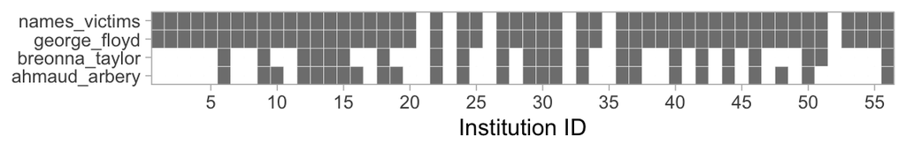

```r
quick_plot(mention_victims_names)
```

Which ones did not mention George Floyd? 21, 23, 26, 32, 35, 52. We manually verified each of these statements did not mention George Floyd.

### 2. Reference to the Black community specifically

- Statement must contain “black*” or “african[-]american*” at least once.

```r
x_black <- word_df %>%
    filter(grepl("\\<black", word)) %>%
    pull(random_id) %>%
    unique() %>%
    sort()

x_african_american <- ngram2_df %>%
    filter(grepl("\\<african american", ngram2)) %>%
    pull(random_id) %>%
    unique() %>%
    sort()
```

```r
mention_black_community <- bind_rows(
    reshape_criterion(analytic_df, "black", x_black) %>%
        mutate(category_type = "sub"),
    reshape_criterion(analytic_df, "african_american", x_african_american) %>%
        mutate(category_type = "sub"),
    reshape_criterion(
        analytic_df,
        "mentions_black_community",
        c(x_black, x_african_american)
    ) %>%
        mutate(category_type = "main")
) %>%
    mutate(category = "mentions_black_community")
```

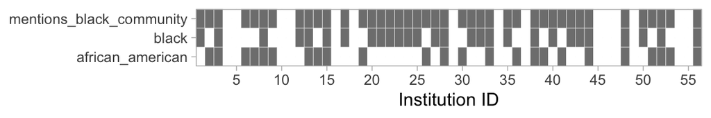

```r
quick_plot(mention_black_community)
```

### 3. Reference to the role of the police

- Statement must contain any of the following at least once:
  - “police*” (i.e., not “policing” or “policy”)
  - “police officer*”
  - “law enforcement”

```r
x_police <- word_df %>%
    filter(grepl("\\<police", word)) %>%
    pull(random_id) %>%
    unique() %>%
    sort()

x_law_enforcement <- ngram2_df %>%
    filter(ngram2 == "law enforcement") %>%
    pull(random_id) %>%
    unique() %>%
    sort()

x_police_officer <- ngram2_df %>%
    filter(grepl("\\<police officer", ngram2)) %>%
    pull(random_id) %>%
    unique() %>%
    sort()
```

```r
mention_police <-
    reshape_criterion(analytic_df, "police", x_police) %>%
    mutate(category_type = "sub")

mention_police_officer <-
    reshape_criterion(analytic_df, "police_officer", x_police_officer) %>%
    mutate(category_type = "sub")

mention_law_enforcement <-
    reshape_criterion(analytic_df, "law_enforcement", x_law_enforcement) %>%
    mutate(category_type = "sub")

role_of_police <-
    bind_rows(
        mention_police,
        mention_police_officer,
        mention_law_enforcement,
        reshape_criterion(
            analytic_df,
            "role_of_police",
            c(x_police, x_law_enforcement, x_police_officer)
        ) %>%
            mutate(category_type = "main")
    ) %>%
    mutate(category = "role_of_police")
```

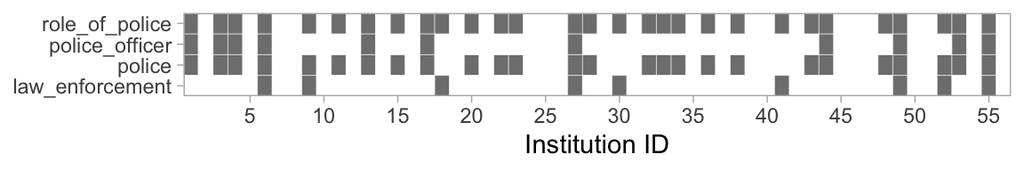

```r
quick_plot(role_of_police)
```

### 4. Specifies the act resulting in Floyd’s death

- Statement must either:
  - Contain “murder*”, “kill*”, “suffocat*” at least once or
  - Contain {“knee*” or “knelt”} and “neck” in the same sentence.

```r
x_murder <- word_df %>%
    filter(grepl("\\<murder", word)) %>%
    pull(random_id) %>%
    unique() %>%
    sort()

x_kill <- word_df %>%
    filter(grepl("\\<kill", word)) %>%
    pull(random_id) %>%
    unique() %>%
    sort()

x_suffocate <- word_df %>%
    filter(grepl("\\<suffoca", word)) %>%
    pull(random_id) %>%
    unique() %>%
    sort()

x_kneeling_neck <- sentence_df %>%
    filter(grepl("\\sknee|\\sknelt", sentence),
           grepl("\\sneck", sentence)) %>%
    pull(random_id) %>%
    unique() %>%
    sort()
```

```r
mention_murder <-
    reshape_criterion(analytic_df, "murder", x_murder) %>%
    mutate(category_type = "sub")

mention_kill <-
    reshape_criterion(analytic_df, "killing", x_kill) %>%
    mutate(category_type = "sub")

mention_suffocate <-
    reshape_criterion(analytic_df, "suffocating", x_suffocate) %>%
    mutate(category_type = "sub")

mention_kneeling_neck <-
    reshape_criterion(analytic_df, "kneeling_on_neck", x_kneeling_neck) %>%
    mutate(category_type = "sub")

describes_the_act <-
    bind_rows(
        mention_murder,
        mention_kill,
        mention_suffocate,
        mention_kneeling_neck,
        reshape_criterion(
            analytic_df,
            "describes_the_act",
            c(x_murder, x_kill, x_suffocate, x_kneeling_neck)
        ) %>%
            mutate(category_type = "main")
    ) %>%
    mutate(category = "describes_the_act")
```

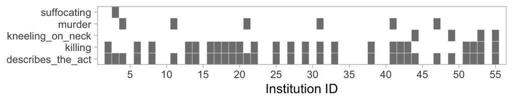

```r
quick_plot(describes_the_act)
```

### 5. Explicitly naming racism

- Statement must contain any of the following at least once:
  - “racist*” (e.g., racist or racists)
  - “racism*”
  - “white suprem*” (e.g., white supremacy)

```r
x_racist <- word_df %>%
    filter(grepl("\\<racist", word)) %>%
    pull(random_id) %>%
    unique() %>%
    sort()

x_racism <- word_df %>%
    filter(grepl("\\<racism", word)) %>%
    pull(random_id) %>%
    unique() %>%
    sort()

x_white_supremacy <- ngram2_df %>%
    filter(grepl("\\<white suprem", ngram2)) %>%
    pull(random_id) %>%
    unique() %>%
    sort()
```

```r
mention_racist <-
    reshape_criterion(analytic_df, "racist", x_racist) %>%
    mutate(category_type = "sub")

mention_racism <-
    reshape_criterion(analytic_df, "racism", x_racism) %>%
    mutate(category_type = "sub")

mention_white_supremacy <-
    reshape_criterion(analytic_df, "white_supremacy", x_white_supremacy) %>%
    mutate(category_type = "sub")

role_of_racism <-
    bind_rows(
        mention_racist,
        mention_racism,
        mention_white_supremacy,
        reshape_criterion(
            analytic_df,
            "role_of_racism",
            c(x_racist, x_racism, x_white_supremacy)
        ) %>%
            mutate(category_type = "main")
    ) %>%
    mutate(category = "role_of_racism")
```

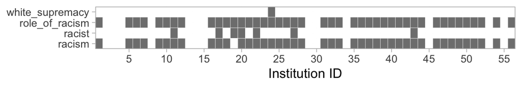

```r
quick_plot(role_of_racism)
```

### 6. Active support against racism

- Statement must contain any of the following at least once:
  - “anti[-]racis*” (e.g., anti-racism, anti-racists)
  - “Black Lives Matter” (as a trigram) or “BlackLivesMatter” (word) or “BLM” (word)
  - “Black”, “Lives”, and “Matter” in the same sentence (e.g., “the lives of our Black community matter”).

```r
antiracist1 <- word_df %>%
    filter(grepl("\\<antiraci|\\<anti-raci", word)) %>%
    pull(random_id) %>%
    unique() %>%
    sort()

antiracist2 <- ngram2_df %>%
    filter(grepl("\\<anti raci|\\<anti-raci", ngram2)) %>%
    pull(random_id) %>%
    unique() %>%
    sort()

x_antiracism <- sort(unique(c(antiracist1, antiracist2)))

x_blm <- word_df %>%
  filter(grepl("\\<blm|\\<blacklivesmatter", word)) %>%
  pull(random_id) %>%
  unique() %>%
  sort()

x_blm2 <- ngram3_df %>%
  filter(grepl("black lives matter*", ngram3)) %>%
  pull(random_id) %>%
  unique() %>%
  sort()

x_blm3 <- sentence_df %>%
  filter(grepl("black", sentence) &
           grepl("lives", sentence) &
           grepl("matter", sentence)) %>%
  pull(random_id) %>%
  unique() %>%
  sort()
```

```r
mention_antiracist <-
    reshape_criterion(analytic_df, "antiracism", x_antiracism) %>%
    mutate(category_type = "sub")

mention_blm <-
    reshape_criterion(analytic_df, "black_lives_matter", c(x_blm, x_blm2)) %>%
    mutate(category_type = "sub")

mention_active_support <- bind_rows(
    mention_antiracist,
    mention_blm,
    reshape_criterion(analytic_df, "active_support", c(x_antiracism, x_blm, x_blm2)) %>%
        mutate(category_type = "main")
) %>%
    mutate(category = "active_support")
```

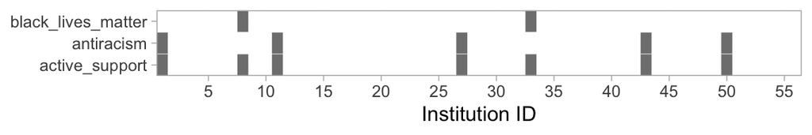

```r
quick_plot(mention_active_support)
```

### 7. Reference to negative sequelae resulting from racism

Statement contains “inequal*”, “injustice”, “inequit*”, or “disparit*” at least once.

```r
x_inequal <- word_df %>%
    filter(grepl("\\<inequal", word)) %>%
    pull(random_id) %>%
    unique() %>%
    sort()

x_injustice <- word_df %>%
    filter(grepl("\\<injustice", word)) %>%
    pull(random_id) %>%
    unique() %>%
    sort()

x_inequity <- word_df %>%
    filter(grepl("\\<inequit", word)) %>%
    pull(random_id) %>%
    unique() %>%
    sort()

x_disparity <- word_df %>%
    filter(grepl("\\<disparit", word)) %>%
    pull(random_id) %>%
    unique() %>%
    sort()
```

```r
mention_inequal <-
    reshape_criterion(analytic_df, "inequality", x_inequal) %>%
    mutate(category_type = "sub")

mention_injustice <-
    reshape_criterion(analytic_df, "injustice", x_injustice) %>%
    mutate(category_type = "sub")

mention_inequity <-
    reshape_criterion(analytic_df, "inequity", x_inequity) %>%
    mutate(category_type = "sub")

mention_disparity <-
    reshape_criterion(analytic_df, "disparity", x_disparity) %>%
    mutate(category_type = "sub")

mention_enemy_words <- bind_rows(
    mention_inequal,
    mention_injustice,
    mention_inequity,
    mention_disparity,
    reshape_criterion(
        analytic_df,
        "enemy_words",
        c(x_inequal, x_injustice, x_inequity, x_disparity)
    ) %>%
        mutate(category_type = "main")
) %>%
    mutate(category = "enemy_words")
```

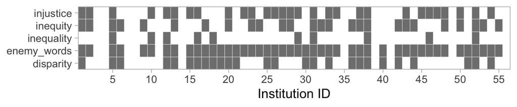

```r
quick_plot(mention_enemy_words)
```

### 8. Use of hopeful language

- Statement contains:
  - “communit*”,
  - “inclus*”,
  - “justice*”,
  - “divers*”,
  - “solidarity”,
  - “equal*”,
  - “equit*”, or
  - “support*”

at least once.

```r
x_community <- word_df %>%
    filter(grepl("\\<communit", word)) %>%
    pull(random_id) %>%
    unique() %>%
    sort()

mention_community <-
    reshape_criterion(analytic_df, "community", x_community) %>%
    mutate(category_type = "sub")

x_inclusion <- word_df %>%
    filter(grepl("\\<inclus", word)) %>%
    pull(random_id) %>%
    unique() %>%
    sort()

mention_inclusion <-
    reshape_criterion(analytic_df, "inclusion", x_inclusion) %>%
    mutate(category_type = "sub")

x_justice <- word_df %>%
    filter(grepl("\\<justice", word)) %>%
    pull(random_id) %>%
    unique() %>%
    sort()

mention_justice <-
    reshape_criterion(analytic_df, "justice", x_justice) %>%
    mutate(category_type = "sub")

x_diversity <- word_df %>%
    filter(grepl("\\<divers", word)) %>%
    pull(random_id) %>%
    unique() %>%
    sort()

mention_diversity <-
    reshape_criterion(analytic_df, "diversity", x_diversity) %>%
    mutate(category_type = "sub")

x_solidarity <- word_df %>%
    filter(grepl("\\<solidarity", word)) %>%
    pull(random_id) %>%
    unique() %>%
    sort()

mention_solidarity <-
    reshape_criterion(analytic_df, "solidarity", x_solidarity) %>%
    mutate(category_type = "sub")

x_equality <- word_df %>%
    filter(grepl("\\<equal", word)) %>%
    pull(random_id) %>%
    unique() %>%
    sort()

mention_equality <-
    reshape_criterion(analytic_df, "equality", x_equality) %>%
    mutate(category_type = "sub")

x_equity <- word_df %>%
    filter(grepl("\\<equit", word)) %>%
    pull(random_id) %>%
    unique() %>%
    sort()

mention_equity <-
    reshape_criterion(analytic_df, "equity", x_equity) %>%
    mutate(category_type = "sub")

x_support <- word_df %>%
    filter(grepl("\\<support", word)) %>%
    pull(random_id) %>%
    unique() %>%
    sort()

mention_support <-
    reshape_criterion(analytic_df, "support", x_support) %>%
    mutate(category_type = "sub")
```

```r
mention_hopeful_words <- bind_rows(
    mention_community,
    mention_inclusion,
    mention_justice,
    mention_diversity,
    mention_solidarity,
    mention_equality,
    mention_equity,
    mention_support,
    reshape_criterion(
        analytic_df,
        "hopeful_words",
        c(
            x_support,
            x_equity,
            x_equality,
            x_solidarity,
            x_diversity,
            x_justice,
            x_inclusion,
            x_community
        )
    ) %>%
        mutate(category_type = "main")
) %>%
    mutate(category = "hopeful_words")
```

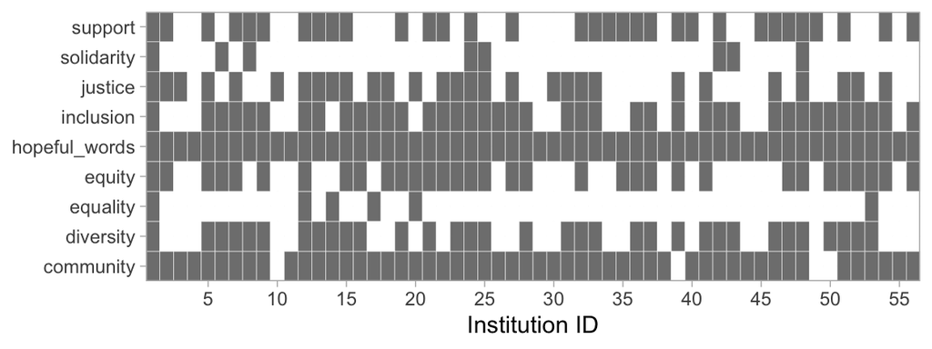

```r
quick_plot(mention_hopeful_words)
```

## Results

### Plot of all criteria and institutions (reordered)

```r
t_faces <-
    rev(c(
        "bold",
         rep("plain", 3),
        "bold",
         rep("plain", 2),
        "bold",
        rep("plain", 3),
        "bold",
        rep("plain", 4),
        "bold",
        rep("plain", 3),
        "bold",
        rep("plain", 2),
        "bold",
        rep("plain", 4),
        "bold",
        rep("plain", 8)
    ))
```

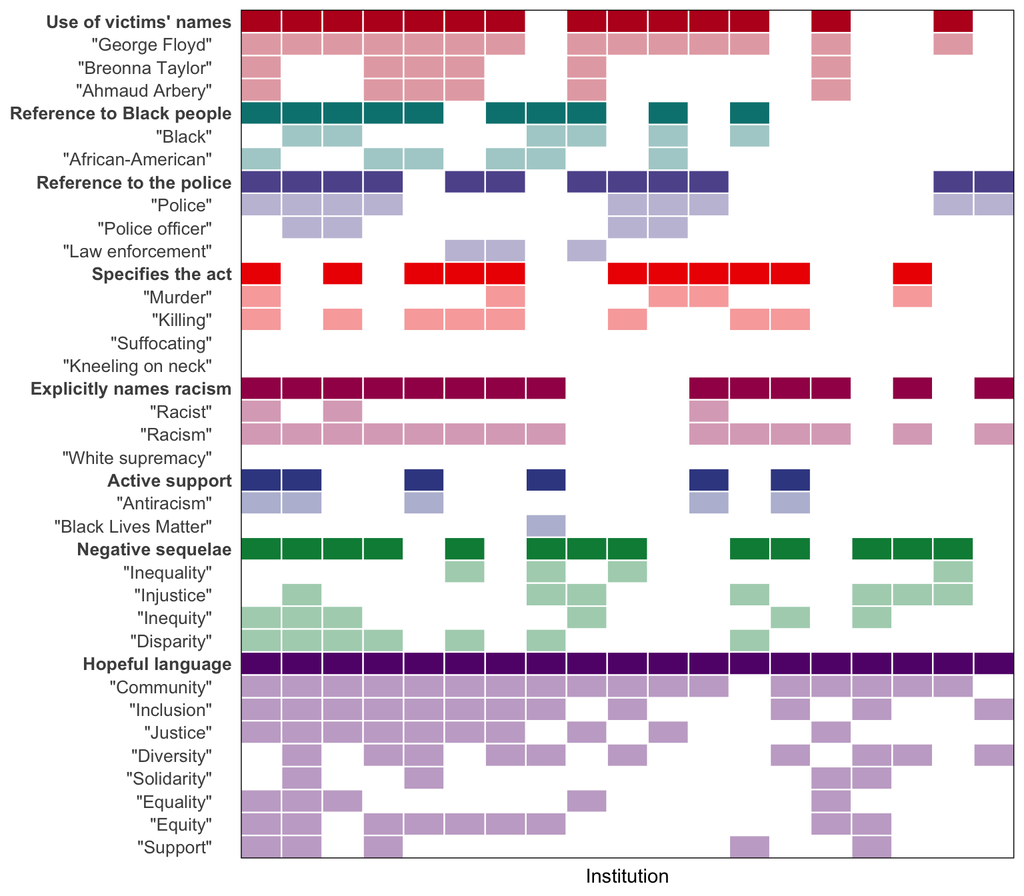

```r
p1 <- ggplot(
    summary_df,
    aes(
        x = p_rank,
        y = criterion_cat,
        fill = interaction(category),
        alpha = interaction(category_type, value)
    )
) +
    geom_tile(color = "white", size = .4) +
    scale_alpha_manual(NULL, values = c(0, 0, 1, .4)) +
    theme_minimal() +
    scale_x_continuous("Institution", expand = c(0, 0)) +
    scale_y_discrete(NULL, expand = c(0, 0)) +
    theme(
        legend.position = "none",
        panel.border = element_rect(fill = NA, color = "black"),
        axis.text.x = element_blank(),
        axis.text.y = element_text(face = t_faces,
                                   hjust = 1,
                                   size = 10),
        axis.title.x = element_text(size = 11),
        panel.grid = element_blank(),
    ) +
  # coord_equal() +
    ggsci::scale_fill_aaas()
print(p1)
```

### Proportion of major criteria covered by each statement

```r
summary_df %>%
  filter(category_type == "main") %>%
  group_by(institution_id) %>%
  summarize(sum_main_cats = sum(value),
            prop_main_cats = mean(value)) %>%
  arrange(desc(prop_main_cats)) %>%
  datatable(rownames = FALSE)
```

| institution_id | sum_main_cats | prop_main_cats |
| --- | --- | --- |
| 12 | 8 | 1 |
| 13 | 7 | 0.875 |
| 16 | 7 | 0.875 |
| 4 | 6 | 0.75 |
| 6 | 6 | 0.75 |
| 8 | 6 | 0.75 |
| 17 | 6 | 0.75 |
| 18 | 6 | 0.75 |
| 19 | 6 | 0.75 |
| 1 | 5 | 0.625 |

[output cut: 9 more lines]

### Summary table of all criteria and institutions

```r
summary_df %>%
    group_by(criterion_cat) %>%
    summarize(n_true = sum(value), p_true = mean(value)) %>%
    arrange(desc(criterion_cat)) %>%
    mutate(criterion_cat = gsub('\\"', "", as.character(criterion_cat))) %>%
    datatable(rownames = FALSE)
```

| criterion_cat | n_true | p_true |
| --- | --- | --- |
| Use of victims' names | 14 | 0.736842105263158 |
| George Floyd | 14 | 0.736842105263158 |
| Breonna Taylor | 6 | 0.315789473684211 |
| Ahmaud Arbery | 6 | 0.315789473684211 |
| Reference to Black people | 10 | 0.526315789473684 |
| Black | 6 | 0.315789473684211 |
| African-American | 6 | 0.315789473684211 |
| Reference to the police | 12 | 0.631578947368421 |
| Police | 9 | 0.473684210526316 |
| Police officer | 4 | 0.210526315789474 |

[output cut: 27 more lines]

### Summary table of major criteria

```r
summary_df %>%
    filter(category_type == "main") %>%
    group_by(criterion_cat) %>%
    summarize(n_true = sum(value), p_true = mean(value)) %>%
    arrange(desc(criterion_cat)) %>%
    mutate(criterion_cat = gsub('\\"', "", as.character(criterion_cat))) %>%
    datatable(rownames = FALSE)
```

| criterion_cat | n_true | p_true |
| --- | --- | --- |
| Use of victims' names | 14 | 0.736842105263158 |
| Reference to Black people | 10 | 0.526315789473684 |
| Reference to the police | 12 | 0.631578947368421 |
| Specifies the act | 11 | 0.578947368421053 |
| Explicitly names racism | 14 | 0.736842105263158 |
| Active support | 6 | 0.315789473684211 |
| Negative sequelae | 13 | 0.684210526315789 |
| Hopeful language | 19 | 1 |

### Summary table by institution

```r
left_join(
  summary_df %>%
    group_by(institution_id) %>%
    summarize(all_criterion = sum(value)),
  summary_df %>%
    filter(category_type == "main") %>%
    group_by(institution_id) %>%
    summarize(main_criterion = sum(value))
) %>%
  arrange(desc(main_criterion)) %>%
  datatable(rownames = FALSE)
```

| institution_id | all_criterion | main_criterion |
| --- | --- | --- |
| 12 | 26 | 8 |
| 13 | 20 | 7 |
| 16 | 24 | 7 |
| 4 | 17 | 6 |
| 6 | 19 | 6 |
| 8 | 19 | 6 |
| 17 | 18 | 6 |
| 18 | 13 | 6 |
| 19 | 13 | 6 |
| 1 | 12 | 5 |

[output cut: 9 more lines]